# Public Health Project - Exploration & Cleaning

Julia Bui Xuan, Simone Farallo, Michele Salvaterra, Luca Sammarini, Eugenio Tarolli Bramè

Il presente progetto si propone di esaminare quattro dataset relativi alla situazione sanitaria di una piccola cittadina tedesca nel periodo compreso tra il 1984 e il 1988. I dataset che andremo ad analizzare sono:

1. estratto del **German health registry** per l’anno 1984 relativo ad una piccola cittadina (dataset reale openData modificato). Le variabili che lo compongono sono le seguenti (e sono relative alla situazione del cittadino all’inizio del 1984):
- idnum: codice identificativo del soggetto
- smoke (yes or no): se il soggetto fuma
- sex (Female or Male)
- married (yes or no): se è coniugato
- kids (yes or no): se il soggetto ha figli
- work (yes or no): se lavora
- education ( no/low = da nessuna a diploma scuola media inferiore;medium/high = diploma scuola media superiore o oltre)
- age (numerica, in anni)
2. **Registro tumori tedesco**(dataset simulato) relativo al mese di Gennaio 1984. Le variabili che lo compongono sono le seguenti:
- idnum: codice identificativo del paziente
- stadio (I, II, III, IV): stadio del tumore alla diagnosi
- incidenza: data di diagnosi del tumore
- tipo di tumore: seno, polmone, colon, altro
- geneticm: fattore genetico (1=positivo, 0=negativo)
3. **Schede di dimissione ospedaliera** dei soggetti ricoverati in Germania tra gennaio 1984 e ottobre 1984 per trattamenti oncologici (dataset simulato):
- idnum: codice identificativo del soggetto
- Prestazione: tipo di trattamento ricevuto durante il ricovero (chirurgica, chemioterapica o radioterapica)
- data prestazione: data del trattamento
- dimissione: data di dimissione dall’ospedale
- ospedale: codice univoco dell’ospedale
4. Estratto del **Registro di mortalità** della cittadina tedesca che riporta la mortalità dal 1984 al 1988 e lo stato in vita alla fine del 1988(dataset simulato):
- idnum: codice identificativo del cittadino
- dead: stato in vita alla data enddate
- enddate: data di ultima osservazione (se dead=1 data di morte)

In questa prima fase l’obiettivo è quello di riportare le statistiche descrittive in una tabella per ciascun dataset, con particolare attenzione alla presenza di dati mancanti, incongruenze tra date e record ripetuti che potrebbero creare problemi in fase di linkage e analisi. Saranno segnalati nel report i record con dati ripetuti o incongruenze tra date e saranno eliminati per le analisi successive.

# Preliminary operation

Installazione e caricamento dei pacchetti

```r
#install.packages("ggpubr", dependencies=TRUE)
```

```r
library(ggplot2)
library(ggpubr)
```

# Loading datasets

```r
cancer<-read.csv("https://raw.githubusercontent.com/lucasammarini/public-health-german-cancer/main/dataset/Cancerregister.csv", header = TRUE, sep =";")
death<-read.csv("https://raw.githubusercontent.com/lucasammarini/public-health-german-cancer/main/dataset/Deathregister.csv", header = TRUE, sep =";")
GermanH<-read.csv("https://raw.githubusercontent.com/lucasammarini/public-health-german-cancer/main/dataset/GermanH.csv", header = TRUE, sep =";")
sdo<-read.csv("https://raw.githubusercontent.com/lucasammarini/public-health-german-cancer/main/dataset/SDO.csv", header = TRUE, sep =";")
```

```r
head(cancer)
```

```
##   idnum    Stadio  incidenza tipotumore geneticm
## 1     3 Stadio II 13/01/1984    polmone        0
## 2     4 Stadio II 13/01/1984      altro        0
## 3     5 Stadio II 13/01/1984       seno        0
## 4     6 Stadio II 12/01/1984       seno        0
## 5     7  Stadio I 14/01/1984      altro        0
## 6     8 Stadio IV 18/01/1984      altro        0
```

```r
head(death)
```

```
##   idnum dead    enddate
## 1     1    0 1988-12-31
## 2     2    0 1988-12-31
## 3     3    0 1988-12-30
## 4     4    1 1985-12-17
## 5     5    0 1987-08-07
## 6     6    0 1988-10-25
```

```r
head(GermanH)
```

```
##   idnum smoke    sex married kids work   education age
## 1     1   yes Female     yes   no   no medium/high  45
## 2     2    no Female     yes   no   no         low  44
## 3     3    no Female      no   no   no         low  38
## 4     4   yes Female      no   no   no        <NA>  52
## 5     5    no Female      no   no   no medium/high  49
## 6     6    no Female      no   no   no        <NA>  46
```

```r
head(sdo)
```

```
##   idnum    Prestazione dataprestazione dimissione ospedale
## 1  1933     chirurgica      07/04/1984 19/07/1984        8
## 2 10076 chemioterapica      31/03/1984 08/07/1984        8
## 3 10096     chirurgica      25/02/1984 16/07/1984        2
## 4    79     chirurgica      12/05/1984 28/08/1984        4
## 5 10475     chirurgica      13/04/1984 17/08/1984        8
## 6 11010     chirurgica      06/03/1984 23/07/1984        5
```

# Cleaning & Exploration

## Cancer

Controllo dei duplicati.

```r
cancer$idnum[duplicated(cancer$idnum)]
```

```
## [1]  192  363 1933
```

```r
cancer[cancer$idnum== 192,]
```

```
##     idnum    Stadio  incidenza tipotumore geneticm
## 158   192 Stadio IV 20/01/1984       seno        0
## 159   192 Stadio IV 20/01/1984       seno        0
```

```r
cancer[cancer$idnum== 363,]
```

```
##     idnum    Stadio  incidenza tipotumore geneticm
## 305   363 Stadio II 14/01/1984       seno        0
## 306   363 Stadio II 14/01/1984       seno        0
```

```r
cancer[cancer$idnum== 1933,]
```

```
##      idnum   Stadio  incidenza tipotumore geneticm
## 1639  1933 Stadio I 15/01/1984       seno        0
## 1640  1933 Stadio I 15/01/1984       seno        0
```

Rimozione dei duplicati.

```r
cancer <- cancer[-158, ]
cancer <- cancer[-305,]
cancer <- cancer[-1637, ]
```

Controllo della rimozione dei duplicati.

```r
cancer[cancer$idnum== 363,]
```

```
##     idnum    Stadio  incidenza tipotumore geneticm
## 305   363 Stadio II 14/01/1984       seno        0
```

```r
cancer[cancer$idnum== 192,]
```

```
##     idnum    Stadio  incidenza tipotumore geneticm
## 159   192 Stadio IV 20/01/1984       seno        0
```

```r
cancer[cancer$idnum== 1933,]
```

```
##      idnum   Stadio  incidenza tipotumore geneticm
## 1640  1933 Stadio I 15/01/1984       seno        0
```

Si convertono gli spazi vuoti in valori nulli, poiché essi sono dati mancanti.

```r
cancer <- data.frame(lapply(cancer, function(x) ifelse(x == "", NA, x)), stringsAsFactors = FALSE)
```

Controllo e rimozione dei valori nulli.

```r
sum(is.na(cancer))
```

```
## [1] 15
```

```r
cancer <- na.omit(cancer)
```

Ordinamento dei dati in base alla data di incidenza del tumore.

```r
cancer_clean <- cancer[order(cancer$incidenza),]
head(cancer_clean)
```

```
##    idnum     Stadio  incidenza tipotumore geneticm
## 9     11  Stadio II 11/01/1984       seno        0
## 24    29   Stadio I 11/01/1984    polmone        0
## 25    30  Stadio II 11/01/1984       seno        0
## 31    37  Stadio II 11/01/1984    polmone        0
## 32    38 Stadio III 11/01/1984       seno        0
## 37    48  Stadio II 11/01/1984      altro        0
```

```r
cancer_clean$Stadio <- as.factor(cancer_clean$Stadio)
cancer_clean$tipotumore <- as.factor(cancer_clean$tipotumore)
cancer_clean$geneticm <- as.factor(cancer_clean$geneticm)
cancer_clean$incidenza <- as.Date(cancer_clean$incidenza, tryFormats = "%d/%m/%Y" )
```

Controllo ed esplorazione del dataset pulito.

```r
str(cancer_clean)
```

```
## 'data.frame':    9993 obs. of  5 variables:
##  $ idnum     : int  11 29 30 37 38 48 72 79 129 137 ...
##  $ Stadio    : Factor w/ 4 levels "Stadio I","Stadio II",..: 2 1 2 2 3 2 2 1 1 2 ...
##  $ incidenza : Date, format: "1984-01-11" "1984-01-11" ...
##  $ tipotumore: Factor w/ 4 levels "altro","colon",..: 4 3 4 3 4 1 4 4 4 1 ...
##  $ geneticm  : Factor w/ 2 levels "0","1": 1 1 1 1 1 1 1 1 1 1 ...
##  - attr(*, "na.action")= 'omit' Named int [1:9] 484 984 1065 3458 4260 4283 4689 4854 5521
##   ..- attr(*, "names")= chr [1:9] "484" "984" "1065" "3458" ...
```

```r
summary(cancer_clean)
```

```
##      idnum              Stadio       incidenza            tipotumore   geneticm
##  Min.   :    3   Stadio I  :1605   Min.   :1984-01-11   altro  :3247   0:8879
##  1st Qu.: 2967   Stadio II :5505   1st Qu.:1984-01-13   colon  :2061   1:1114
##  Median : 5989   Stadio III:1197   Median :1984-01-15   polmone:2072
##  Mean   : 5978   Stadio IV :1686   Mean   :1984-01-15   seno   :2613
##  3rd Qu.: 8968                     3rd Qu.:1984-01-18
##  Max.   :12000                     Max.   :1984-01-20
```

Si procede all’esplorazione del dataset attraverso alcuni grafici.

Grafico a barre della distribuzione dei pazienti per stadio del tumore.

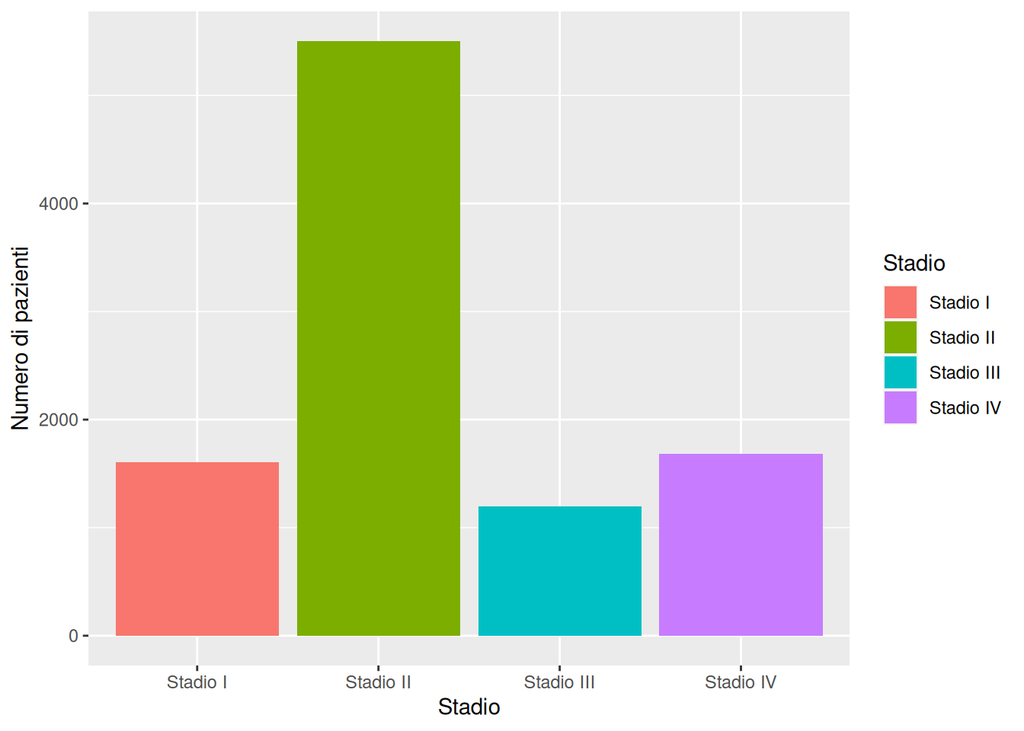

```r
ggplot(cancer_clean, aes(x=Stadio, fill=Stadio)) +
  geom_bar() +
  ylab("Numero di pazienti")
```

Grafico a barre della distribuzione dei pazienti per tipo di tumore.

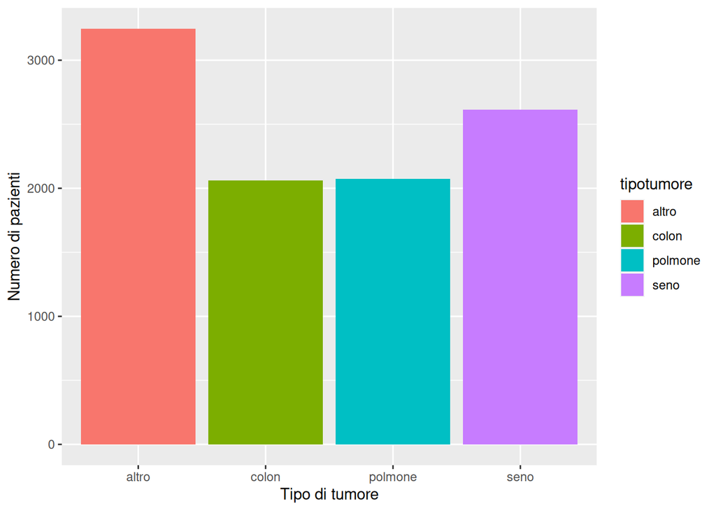

```r
ggplot(cancer_clean, aes(x=tipotumore, fill=tipotumore)) +
  geom_bar()+
  ylab("Numero di pazienti")+
  xlab("Tipo di tumore")
```

Grafico a barre della distribuzione dei pazienti per fattore genetico.

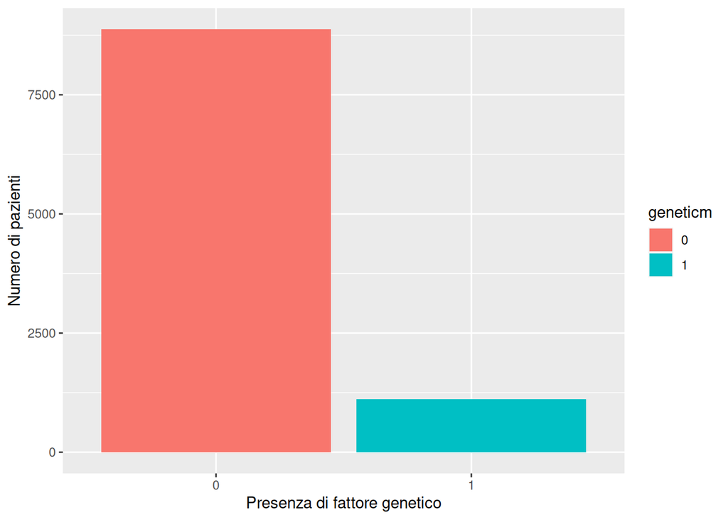

```r
ggplot(cancer_clean, aes(x=geneticm, fill=geneticm)) +
  geom_bar()+
  ylab("Numero di pazienti")+
  xlab("Presenza di fattore genetico")
```

Le due classi sono sbilanciate tra loro.

## Death

```r
str(death)
```

```
## 'data.frame':    7748 obs. of  3 variables:
##  $ idnum  : int  1 2 3 4 5 6 7 8 9 10 ...
##  $ dead   : int  0 0 0 1 0 0 1 1 1 1 ...
##  $ enddate: chr  "1988-12-31" "1988-12-31" "1988-12-30" "1985-12-17" ...
```

Correzione del formato delle colonne ‘dead’ e ‘enddate’.

```r
death$dead = as.factor(death$dead)
death$enddate = as.Date(death$enddate, tryFormats = "%Y-%m-%d" )
str(death)
```

```
## 'data.frame':    7748 obs. of  3 variables:
##  $ idnum  : int  1 2 3 4 5 6 7 8 9 10 ...
##  $ dead   : Factor w/ 2 levels "0","1": 1 1 1 2 1 1 2 2 2 2 ...
##  $ enddate: Date, format: "1988-12-31" "1988-12-31" ...
```

```r
summary(death)
```

```
##      idnum      dead        enddate
##  Min.   :   1   0:5130   Min.   :1984-06-29
##  1st Qu.:1938   1:2618   1st Qu.:1985-11-12
##  Median :3874            Median :1987-05-27
##  Mean   :3874            Mean   :1987-03-31
##  3rd Qu.:5811            3rd Qu.:1988-11-05
##  Max.   :7748            Max.   :1988-12-31
```

```r
dim(death)
```

```
## [1] 7748    3
```

```r
names(death)
```

```
## [1] "idnum"   "dead"    "enddate"
```

Controllo dei dati mancanti.

```r
sum(is.na(death))
```

```
## [1] 0
```

Non sono presenti dati mancanti.

Controllo dei duplicati.

```r
sum(duplicated(death))
```

```
## [1] 0
```

```r
length(unique(death$idnum)) == length(death$idnum)
```

```
## [1] TRUE
```

Non sono presenti duplicati.

Si procede all’esplorazione del dataset attraverso alcuni grafici.

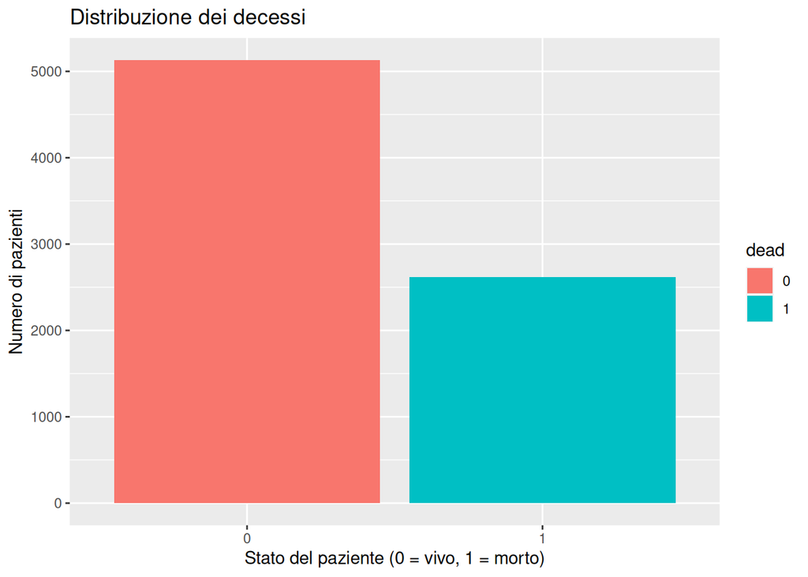

```r
ggplot(death, aes(x = dead, fill = dead)) +
  geom_bar() +
  labs(title = "Distribuzione dei decessi",
       x = "Stato del paziente (0 = vivo, 1 = morto)",
       y = "Numero di pazienti")
```

## GermanH

```r
str(GermanH)
```

```
## 'data.frame':    7748 obs. of  8 variables:
##  $ idnum    : int  1 2 3 4 5 6 7 8 9 10 ...
##  $ smoke    : chr  "yes" "no" "no" "yes" ...
##  $ sex      : chr  "Female" "Female" "Female" "Female" ...
##  $ married  : chr  "yes" "yes" "no" "no" ...
##  $ kids     : chr  "no" "no" "no" "no" ...
##  $ work     : chr  "no" "no" "no" "no" ...
##  $ education: chr  "medium/high" "low" "low" NA ...
##  $ age      : int  45 44 38 52 49 46 62 44 29 35 ...
```

Si analizza quanti valori nulli sono presenti nelle singole colonne.

```r
colSums(is.na(GermanH))
```

```
##     idnum     smoke       sex   married      kids      work education       age
##         0         0         0        22        14         0        36         0
```

Eliminazione dei valori nulli.

```r
GermanH_ok <- na.omit(GermanH)
```

Controllo della riuscita.

```r
colSums(is.na(GermanH_ok))
```

```
##     idnum     smoke       sex   married      kids      work education       age
##         0         0         0         0         0         0         0         0
```

Ricerca dei duplicati.

```r
nrow(GermanH_ok[duplicated(GermanH_ok$idnum),])
```

```
## [1] 0
```

Non sono presenti duplicati.

Correzione del formato delle colonne.

```r
GermanH_ok$smoke <- as.factor(GermanH_ok$smoke)
GermanH_ok$sex <- as.factor(GermanH_ok$sex)
GermanH_ok$married <- as.factor(GermanH_ok$married)
GermanH_ok$kids <- as.factor(GermanH_ok$kids)
GermanH_ok$work <- as.factor(GermanH_ok$work)
GermanH_ok$education <- as.factor(GermanH_ok$education)
str(GermanH_ok)
```

```
## 'data.frame':    7676 obs. of  8 variables:
##  $ idnum    : int  1 2 3 5 12 18 19 20 21 22 ...
##  $ smoke    : Factor w/ 2 levels "no","yes": 2 1 1 1 2 1 1 1 1 1 ...
##  $ sex      : Factor w/ 2 levels "Female","Male": 1 1 1 1 1 1 1 1 1 1 ...
##  $ married  : Factor w/ 2 levels "no","yes": 2 2 1 1 2 2 2 2 2 2 ...
##  $ kids     : Factor w/ 2 levels "no","yes": 1 1 1 1 2 1 1 1 2 1 ...
##  $ work     : Factor w/ 2 levels "no","yes": 1 1 1 1 1 1 1 1 1 1 ...
##  $ education: Factor w/ 2 levels "low","medium/high": 2 1 1 2 2 1 2 1 2 1 ...
##  $ age      : int  45 44 38 49 62 42 37 62 45 48 ...
##  - attr(*, "na.action")= 'omit' Named int [1:72] 4 6 7 8 9 10 11 13 14 15 ...
##   ..- attr(*, "names")= chr [1:72] "4" "6" "7" "8" ...
```

```r
summary(GermanH_ok)
```

```
##      idnum      smoke          sex       married     kids       work
##  Min.   :   1   no :6099   Female:3835   no :1676   no :4222   no :7206
##  1st Qu.:1950   yes:1577   Male  :3841   yes:6000   yes:3454   yes: 470
##  Median :3874
##  Mean   :3887
##  3rd Qu.:5823
##  Max.   :7748
##        education         age
##  low        :6888   Min.   : 26.00
##  medium/high: 788   1st Qu.: 41.00
##                     Median : 45.50
##                     Mean   : 48.21
##                     3rd Qu.: 54.00
##                     Max.   :108.00
```

Esplorazione del dataset pulito attraverso grafici.

```r
colors <- c("#FFA07A", "#ADD8E6")
```

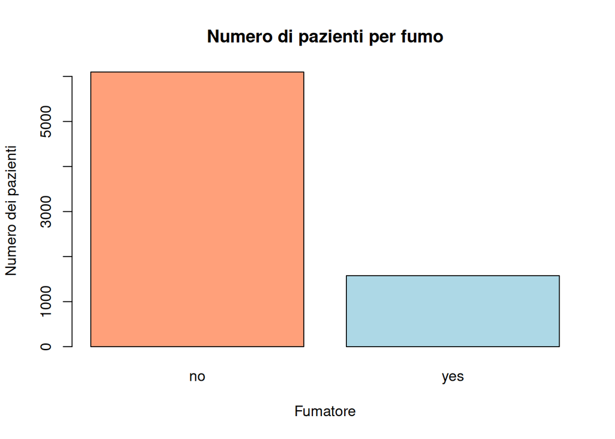

```r
barplot(table(GermanH_ok$smoke), main="Numero di pazienti per fumo", xlab="Fumatore", ylab="Numero dei pazienti", col= colors)
```

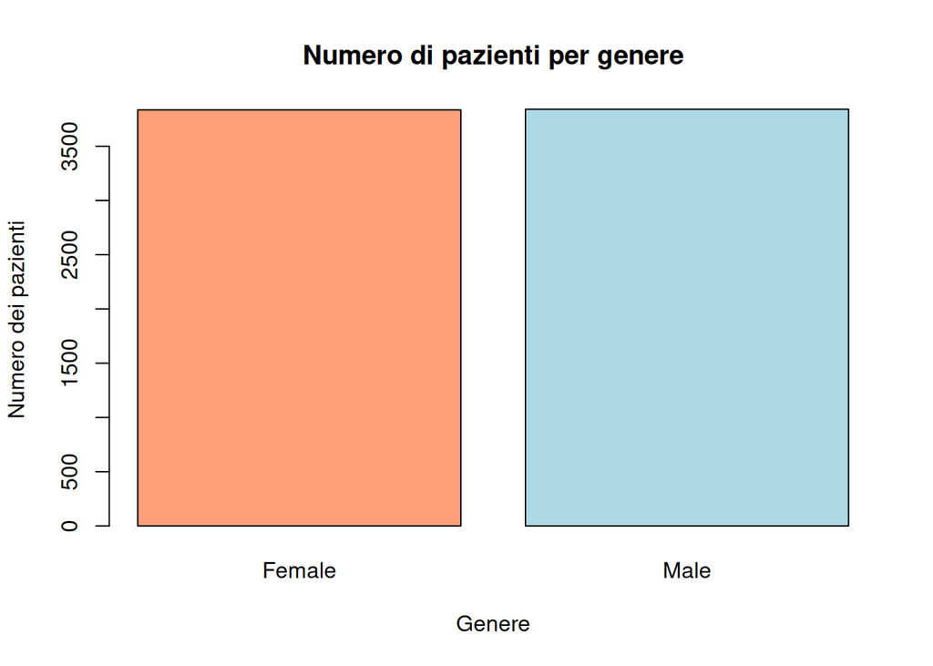

```r
barplot(table(GermanH_ok$sex), main="Numero di pazienti per genere", xlab="Genere", ylab="Numero dei pazienti", col = colors)
```

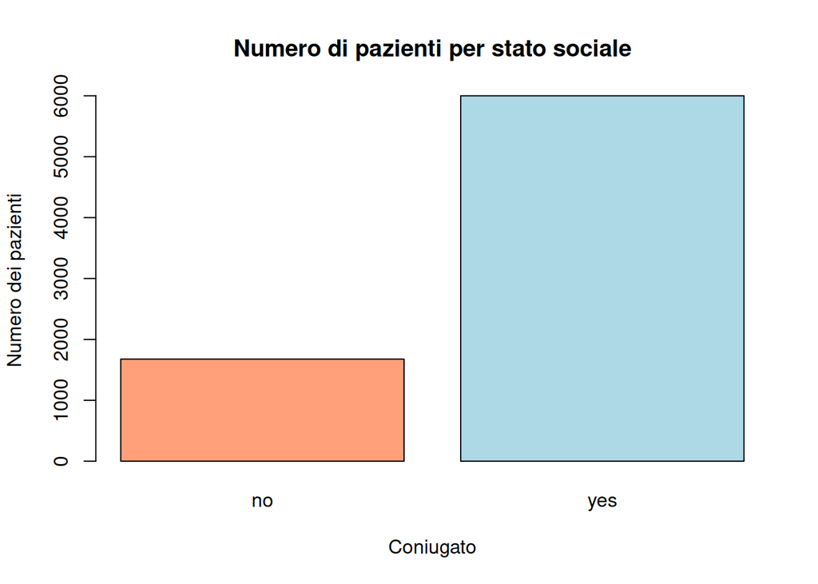

```r
barplot(table(GermanH_ok$married), main="Numero di pazienti per stato sociale", xlab="Coniugato", ylab="Numero dei pazienti", col = colors)
```

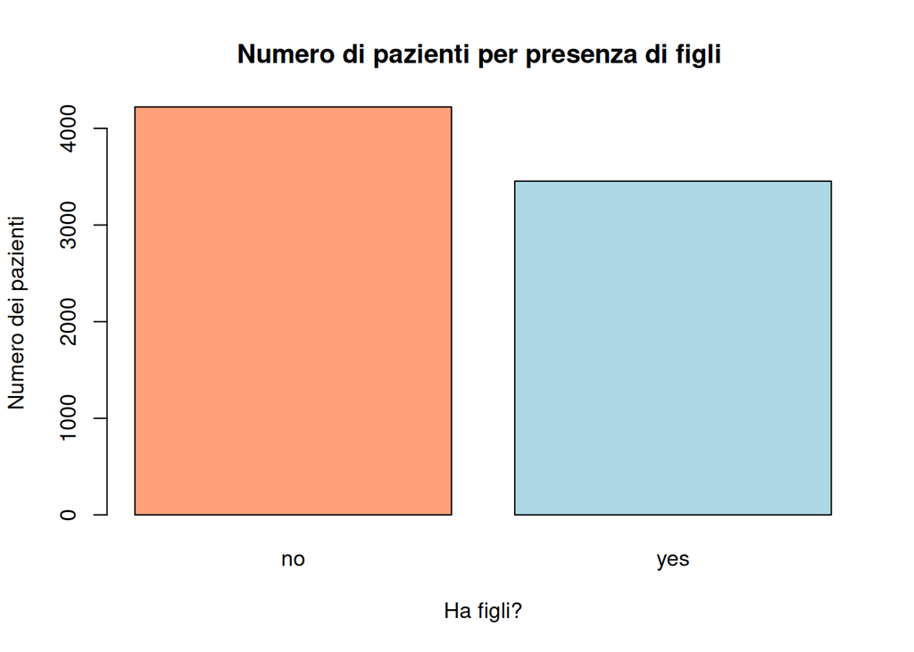

```r
barplot(table(GermanH_ok$kids), main="Numero di pazienti per presenza di figli ", xlab="Ha figli?", ylab="Numero dei pazienti", col= colors)
```

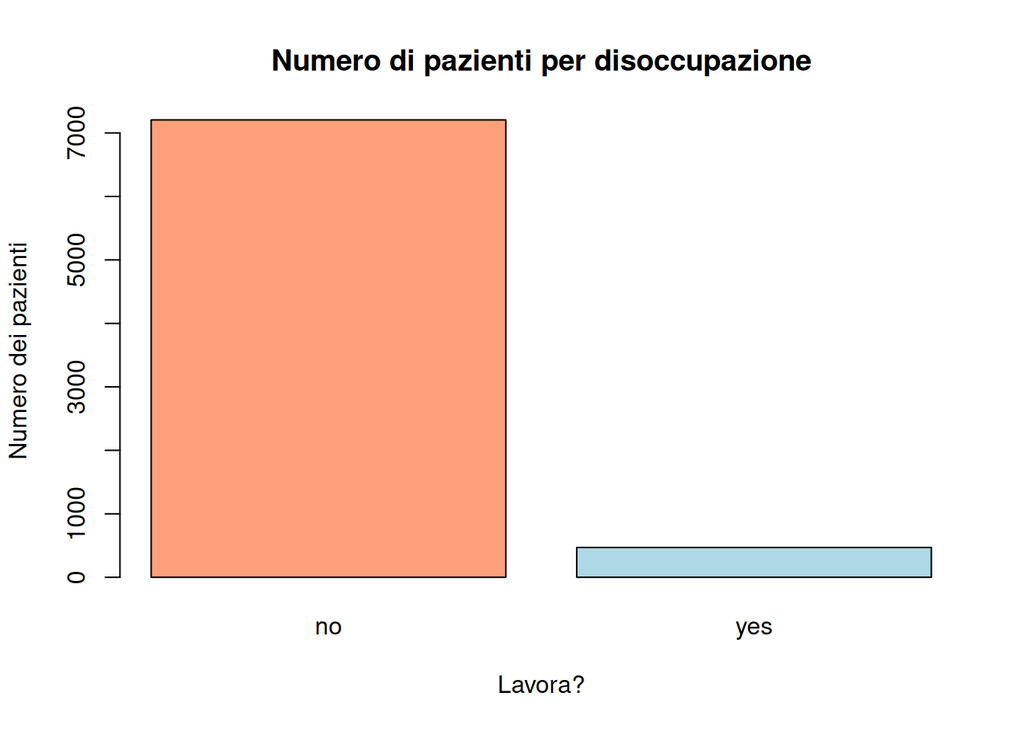

```r
barplot(table(GermanH_ok$work), main="Numero di pazienti per disoccupazione", xlab="Lavora?", ylab="Numero dei pazienti", col = colors)
```

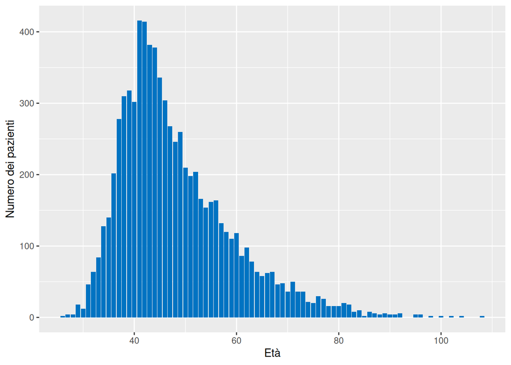

```r
ggplot(GermanH_ok, aes(age)) +
  geom_bar(fill = "#0073C2FF")+xlab('Età')+ylab("Numero dei pazienti")
```

## SDO

```r
str(sdo)
```

```
## 'data.frame':    10002 obs. of  5 variables:
##  $ idnum          : int  1933 10076 10096 79 10475 11010 4402 1788 11318 3164 ...
##  $ Prestazione    : chr  "chirurgica" "chemioterapica" "chirurgica" "chirurgica" ...
##  $ dataprestazione: chr  "07/04/1984" "31/03/1984" "25/02/1984" "12/05/1984" ...
##  $ dimissione     : chr  "19/07/1984" "08/07/1984" "16/07/1984" "28/08/1984" ...
##  $ ospedale       : int  8 8 2 4 8 5 8 3 3 9 ...
```

```r
summary(sdo)
```

```
##      idnum       Prestazione        dataprestazione     dimissione
##  Min.   :    3   Length:10002       Length:10002       Length:10002
##  1st Qu.: 2966   Class :character   Class :character   Class :character
##  Median : 5986   Mode  :character   Mode  :character   Mode  :character
##  Mean   : 5976
##  3rd Qu.: 8966
##  Max.   :12000
##     ospedale
##  Min.   :1.000
##  1st Qu.:3.000
##  Median :5.000
##  Mean   :5.007
##  3rd Qu.:7.000
##  Max.   :9.000
```

Ordinamento del dataset.

```r
sdo <- sdo[order(sdo$idnum), ]
```

Controllo dei duplicati.

```r
nrow(sdo[duplicated(sdo$idnum),])
```

```
## [1] 0
```

Formattazione delle colonne.

```r
sdo$Prestazione <- as.factor(sdo$Prestazione)
sdo$ospedale <- as.factor(sdo$ospedale)
sdo$dataprestazione <- as.Date(sdo$dataprestazione, '%d/%m/%Y')
sdo$dimissione <- as.Date(sdo$dimissione, '%d/%m/%Y')
```

```r
summary(sdo)
```

```
##      idnum               Prestazione   dataprestazione
##  Min.   :    3   chemioterapica:1988   Min.   :1984-01-22
##  1st Qu.: 2966   chirurgica    :3318   1st Qu.:1984-02-19
##  Median : 5986   radioterapica :4696   Median :1984-03-08
##  Mean   : 5976                         Mean   :1984-03-19
##  3rd Qu.: 8966                         3rd Qu.:1984-04-09
##  Max.   :12000                         Max.   :1984-10-07
##                                        NA's   :1
##    dimissione            ospedale
##  Min.   :1984-06-22   1      :1150
##  1st Qu.:1984-07-17   7      :1126
##  Median :1984-08-02   8      :1119
##  Mean   :1984-08-12   9      :1119
##  3rd Qu.:1984-09-01   6      :1110
##  Max.   :1985-02-12   5      :1107
##  NA's   :3            (Other):3271
```

Controllo dei valori nulli.

```r
nrow(sdo[is.na(sdo$Prestazione),])
```

```
## [1] 0
```

```r
nrow(sdo[is.na(sdo$dataprestazione),])
```

```
## [1] 1
```

```r
sdo[is.na(sdo$dataprestazione),]
```

```
##      idnum   Prestazione dataprestazione dimissione ospedale
## 9378  7261 radioterapica            <NA> 1984-07-08        1
```

```r
nrow(sdo[is.na(sdo$dimissione),])
```

```
## [1] 3
```

```r
sdo[is.na(sdo$dimissione),]
```

```
##      idnum    Prestazione dataprestazione dimissione ospedale
## 4263   567     chirurgica      1984-02-13       <NA>        9
## 17    2633 chemioterapica      1984-02-22       <NA>        6
## 7     4402 chemioterapica      1984-02-29       <NA>        8
```

```r
nrow(sdo[is.na(sdo$ospedale),])
```

```
## [1] 0
```

Eliminazione dei valori nulli.

```r
sdo.no.na <- sdo[!is.na(sdo$dataprestazione) & !is.na(sdo$dimissione), ]
nrow(sdo.no.na[is.na(sdo.no.na$Prestazione),])
```

```
## [1] 0
```

```r
nrow(sdo.no.na[is.na(sdo.no.na$dataprestazione),])
```

```
## [1] 0
```

```r
nrow(sdo.no.na[is.na(sdo.no.na$dimissione),])
```

```
## [1] 0
```

```r
nrow(sdo.no.na[is.na(sdo.no.na$ospedale),])
```

```
## [1] 0
```

Controllo della presenza di incongruenze tra date e rimozione dei valori incongruenti.

```r
nrow(sdo.no.na[sdo.no.na$dataprestazione>sdo.no.na$dimissione, ])
```

```
## [1] 42
```

```r
sdo.no.na[sdo.no.na$dataprestazione>sdo.no.na$dimissione, ]
```

```
##      idnum    Prestazione dataprestazione dimissione ospedale
## 5705   180  radioterapica      1984-08-01 1984-07-01        7
## 1103   245 chemioterapica      1984-07-19 1984-07-17        1
## 3096   334     chirurgica      1984-07-20 1984-07-06        1
## 7929  1108  radioterapica      1984-07-07 1984-07-02        4
## 5161  1252  radioterapica      1984-08-03 1984-08-02        8
## 6691  1498     chirurgica      1984-07-18 1984-07-11        9
## 3916  1616     chirurgica      1984-08-16 1984-07-25        8
## 3303  1776 chemioterapica      1984-06-25 1984-06-22        1
## 3840  1980  radioterapica      1984-07-30 1984-07-20        5
## 8483  2046  radioterapica      1984-07-10 1984-06-29        6
## 3054  2243 chemioterapica      1984-07-24 1984-07-20        7
## 1152  2336     chirurgica      1984-09-05 1984-07-18        2
## 1057  2813  radioterapica      1984-09-19 1984-09-13        3
## 8560  3647  radioterapica      1984-08-25 1984-07-19        7
```

[output cut: 28 more lines]

```r
sdo.ok <- sdo.no.na[sdo.no.na$dataprestazione<sdo.no.na$dimissione, ]
```

Statistiche del dataset pulito.

```r
summary(sdo.ok)
```

```
##      idnum               Prestazione   dataprestazione
##  Min.   :    3   chemioterapica:1980   Min.   :1984-01-22
##  1st Qu.: 2972   chirurgica    :3301   1st Qu.:1984-02-19
##  Median : 5991   radioterapica :4674   Median :1984-03-08
##  Mean   : 5979                         Mean   :1984-03-18
##  3rd Qu.: 8966                         3rd Qu.:1984-04-09
##  Max.   :12000                         Max.   :1984-10-07
##
##    dimissione            ospedale
##  Min.   :1984-06-23   1      :1141
##  1st Qu.:1984-07-17   7      :1121
##  Median :1984-08-02   8      :1114
##  Mean   :1984-08-12   9      :1113
##  3rd Qu.:1984-09-01   6      :1105
##  Max.   :1985-02-12   5      :1103
##                       (Other):3258
```

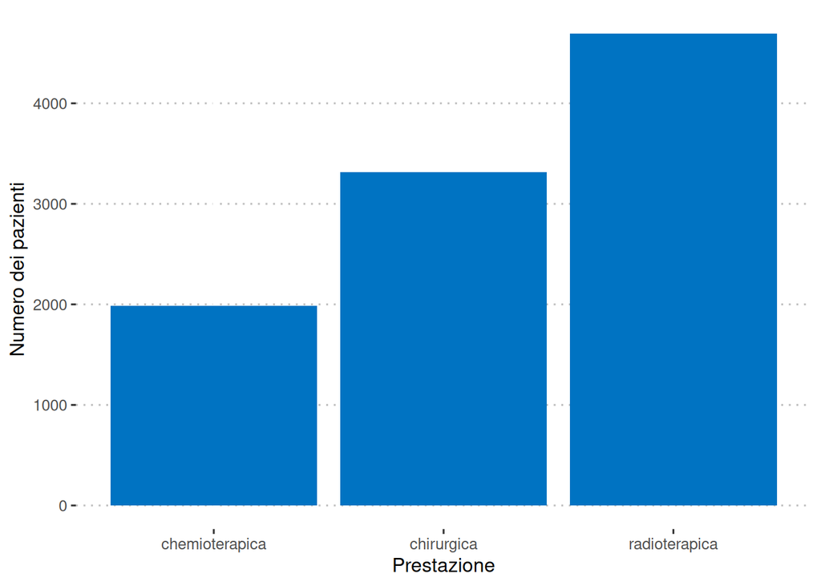

```r
ggplot(sdo, aes(Prestazione)) +
  geom_bar(fill = "#0073C2FF") +
  theme_pubclean()+ylab("Numero dei pazienti")
```

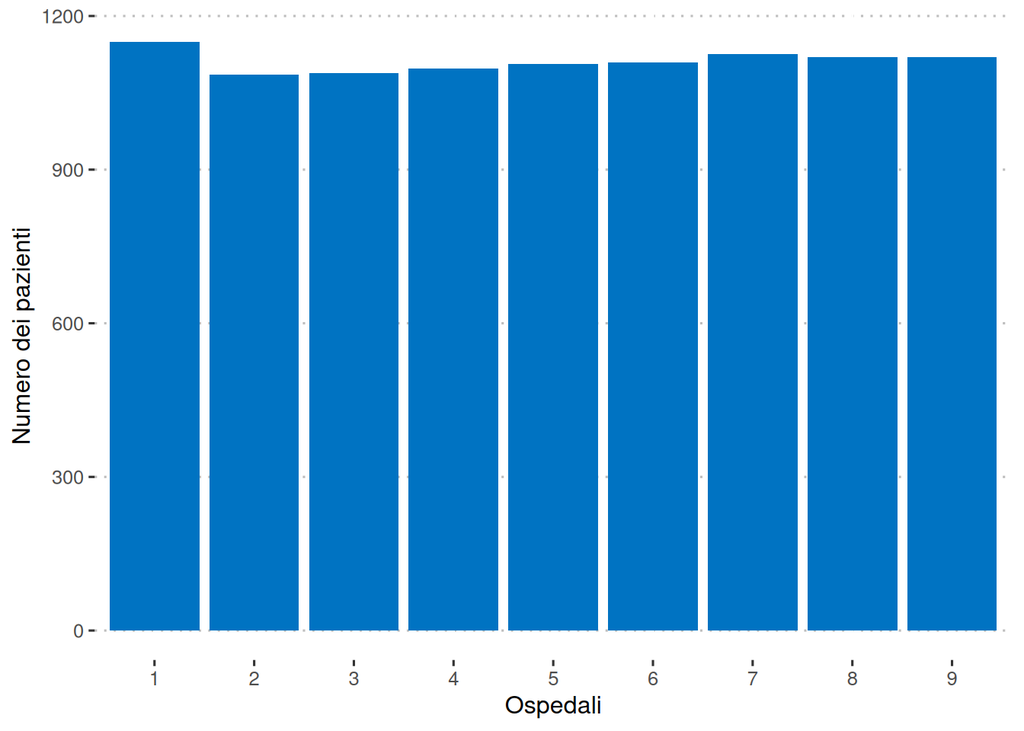

```r
ggplot(sdo, aes(ospedale)) +
  geom_bar(fill = "#0073C2FF") +
  theme_pubclean()+ylab("Numero dei pazienti")+xlab("Ospedali")
```

I dataset sono stati tutti puliti e controllati ed è stata svolta un’analisi esplorativa iniziale. Ora si può passare alla fase di linkage dei dataset per eseguire gli altri task.